# Презентация по лабораторной работе №9

Командная оболочка Midnight Commander

Джаллох Ишмаил

Российский университет дружбы народов, Москва, Россия

11 Апреля 2025

# Информация

## Докладчик

- Джаллох Ишмаил
- Студентка НКА 05-24
- Факультет физико-математических и естественных наук
- Российский университет дружбы народов
- 1032239614@rudn.ru
- https://Isho-Jah.github.io/ru/

# Задание по mc

Я запускал mc, изучал его структуру и меню:

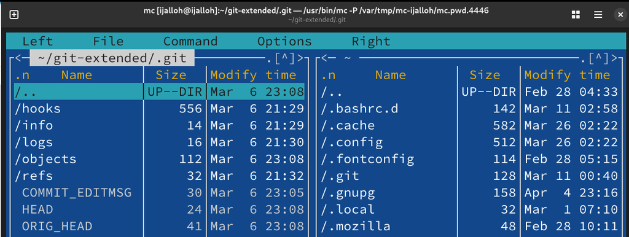

Командная оболочка mc

## Задание по mc

Используя управляющие клавиши я; скопировал файл README.md в домашний каталог:

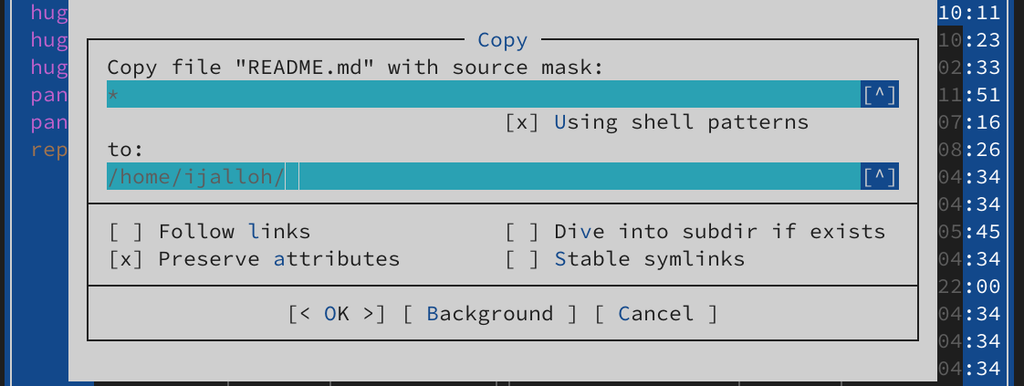

Копирование файла

## Задание по mc

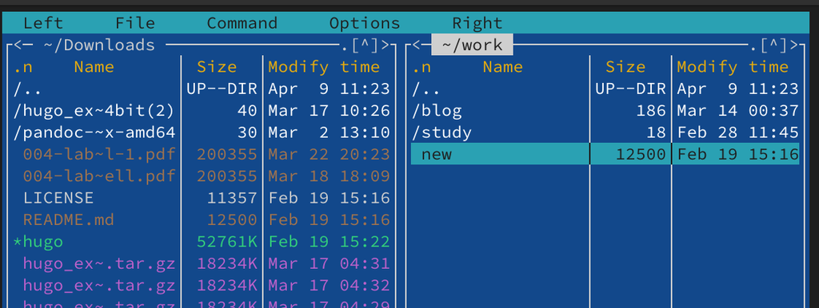

Созданный файл

## Задание по mc

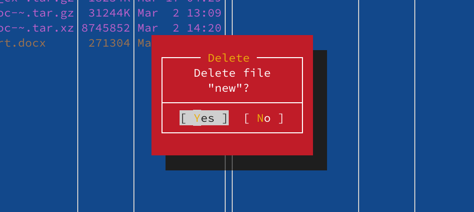

Удаление файла

## Задание по mc

Получил информацию о размере и правах доступа на файл README.md:

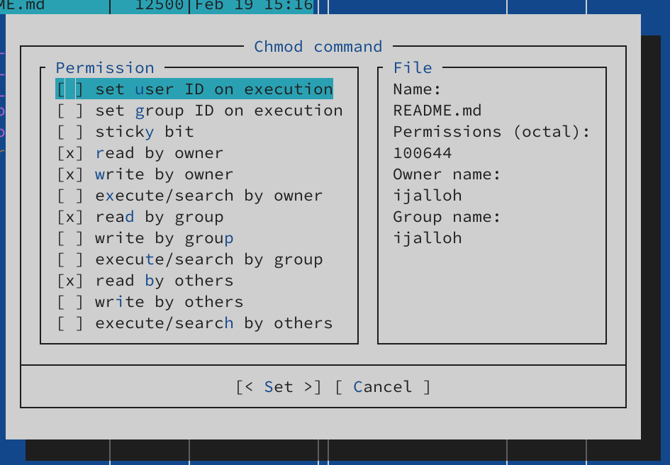

Информация о README.md

## Задание по mc

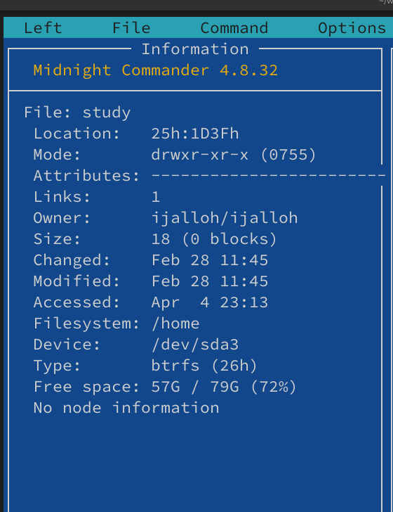

Информфцию о файле

## Задание по mc

Используя возможности подменю Файл; я посмотрел содержаемые текстового файла:

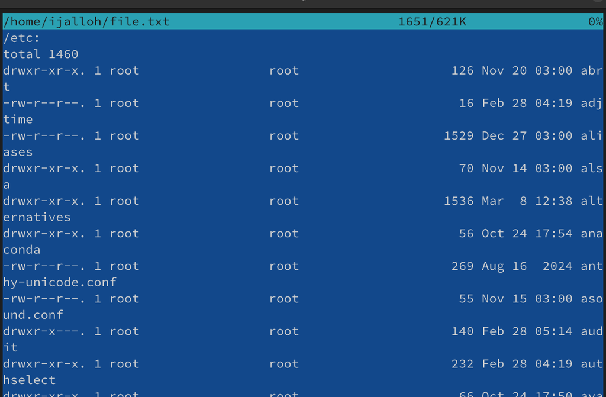

Содержаемые файла

## Задание по mc

редактировал содержаемые текстового файла (abrt на mi):

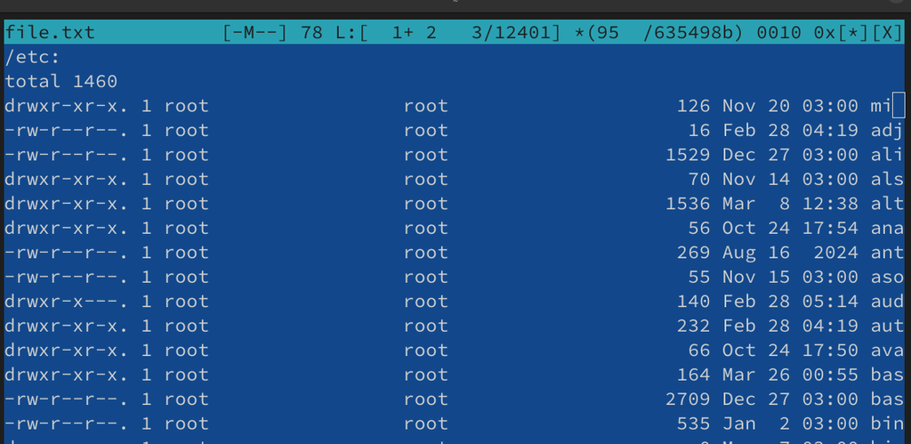

Редактирование файла

## Задание по mc

Создал новый каталог:

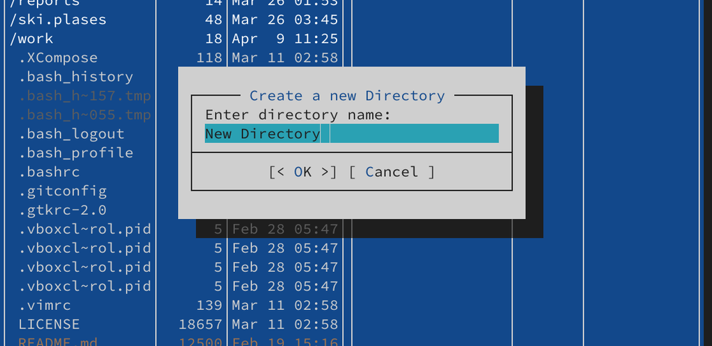

создание каталога

## Задание по mc

и скопировал файл в ,только что созданный каталог:

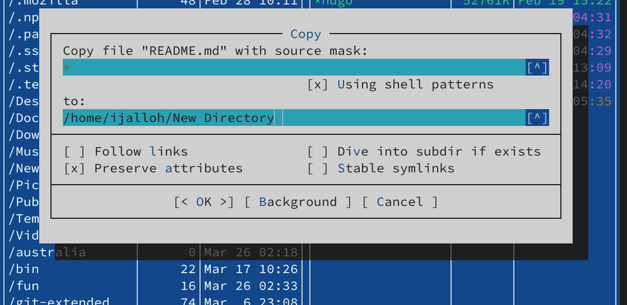

копирование файла

## Задание по mc

С помощью подменю команда можно найти в файловой системе файл с заданными условиями:

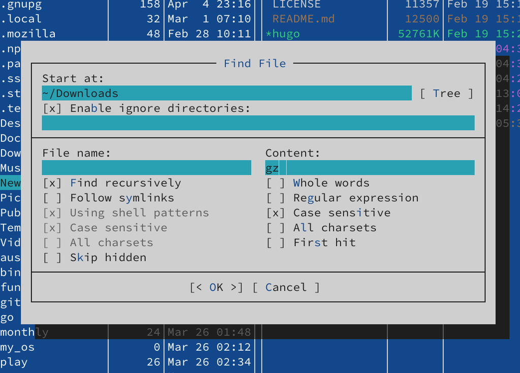

файлы которые содержат gz

## Задание по mc

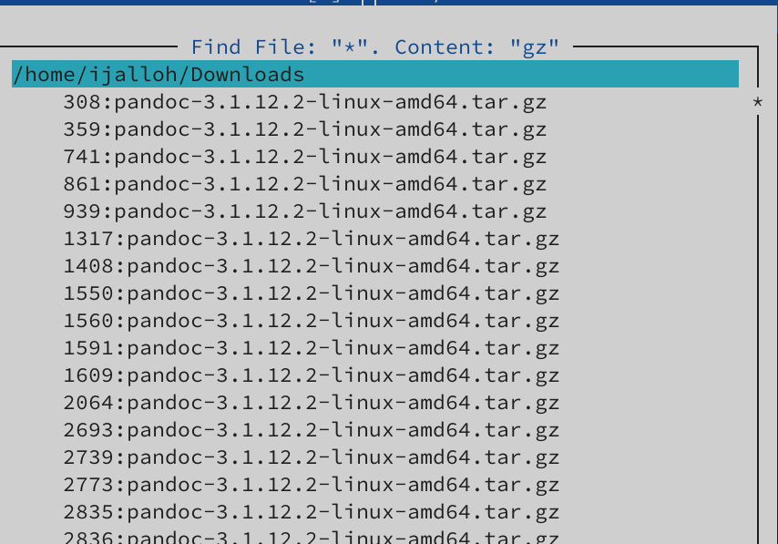

результаты поиска

## Задание по mc

Исользуя подменю команда я повторил одну из предыдущих команд:

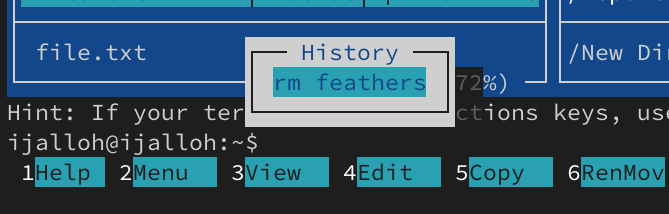

повторение команды

## Задание по mc

Также перешел в домашний каталог и анализировал файл меню и файл расширения:

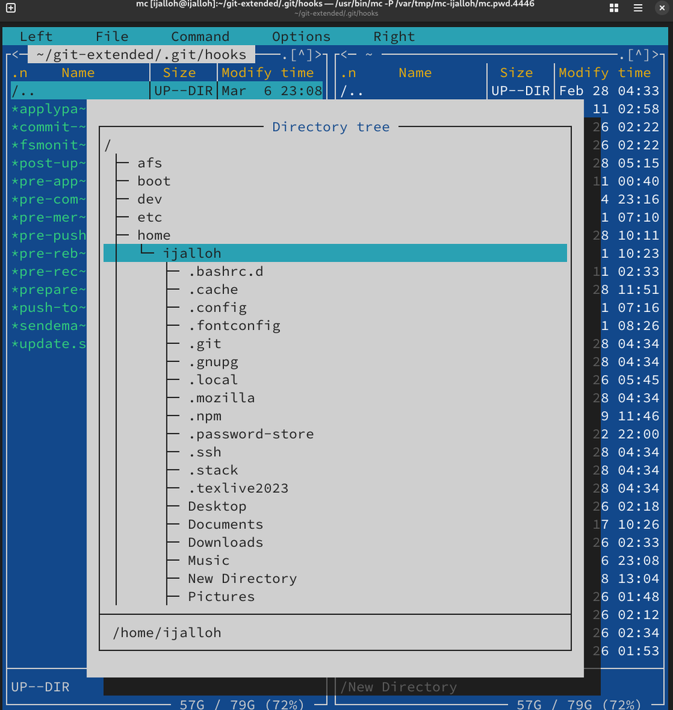

Переход в домашний каталог

## Задание по mc

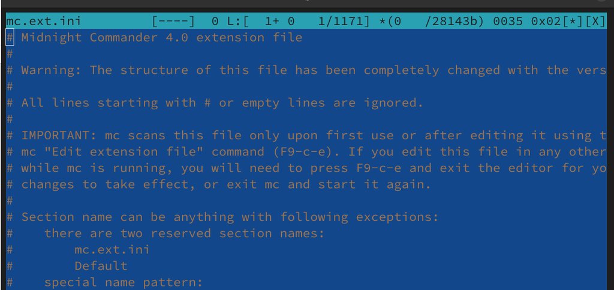

файл расширения

## Задание по mc

Из подменю настройка вызвал окна настройки панели:

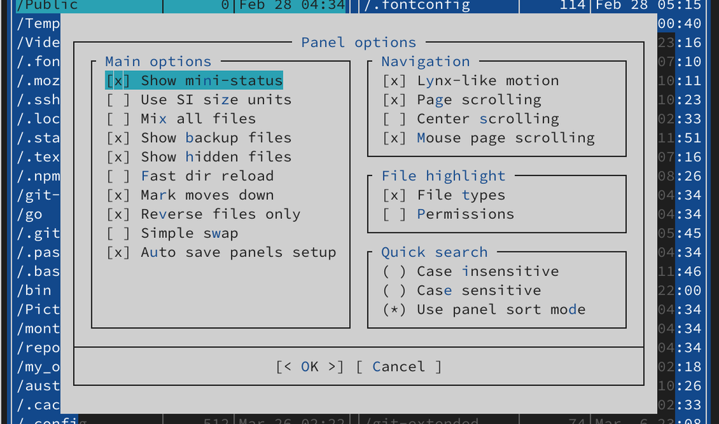

Настройка панели

## Задание по mc

Настройки внешнего вида:

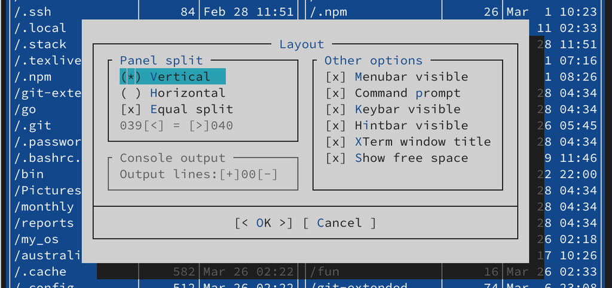

Настройки внешнего вида

# Задание по встроенному редактору mc

С помощью команды touch создал text.txt:

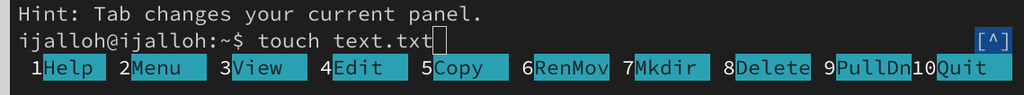

Создание text.txt

## Задание по встроенному редактору mc

Далее открыл его для редактирования с помощью f4 и с shift ctrl ins вставил текст:

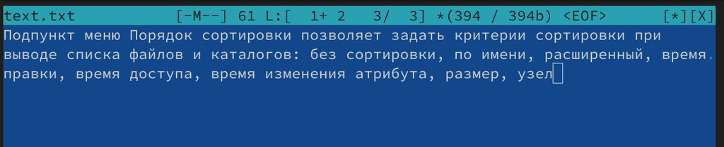

Редактирование text.txt

## Задание по встроенному редактору mc

С помощью f3 выделил текст и удалил выделеные слова f8:

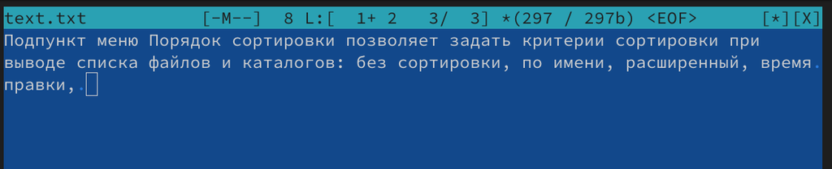

Удаление текста

## Задание по встроенному редактору mc

Перемещал выделенный текст с помощью f6:

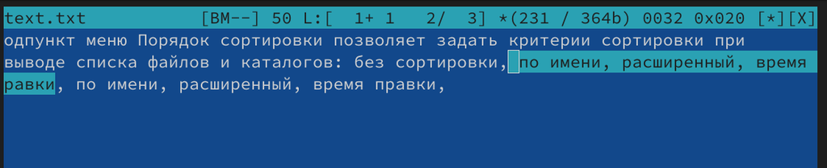

Перемещение текста

## Задание по встроенному редактору mc

Сохранил изменении с помощью f2:

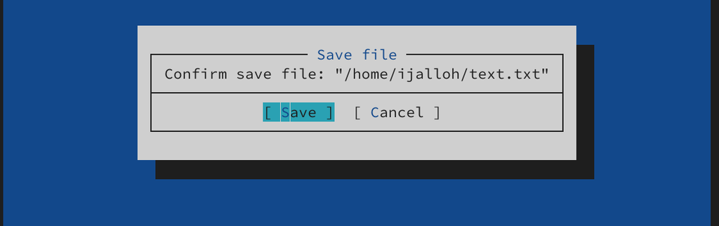

Сохранение изменений в файле

## Задание по встроенному редактору mc

С помощью ctrl-u отменил последнее действие:

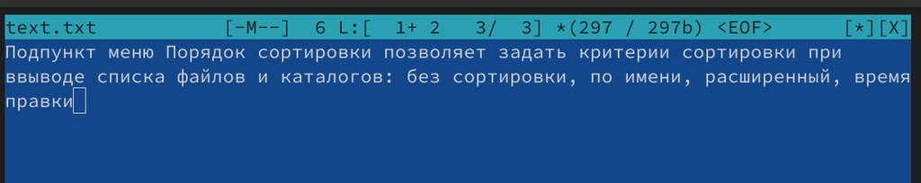

Отменение последнего действия

## Задание по встроенному редактору mc

Используя pg up и pg dn перешел в начало и конец файла и написал некоторый текст. Затем сохранил и закрыл файл:

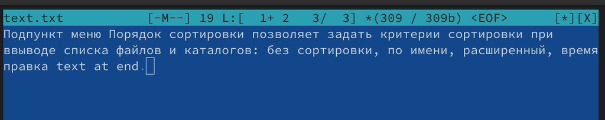

Добавление текста

## Задание по встроенному редактору mc

Открыл файл с исходным текстом на cpp:

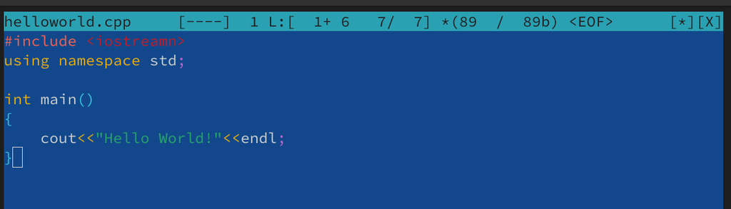

файл cpp

## Задание по встроенному редактору mc

Используя подменю команда я выключил подсветку синтаксиса:

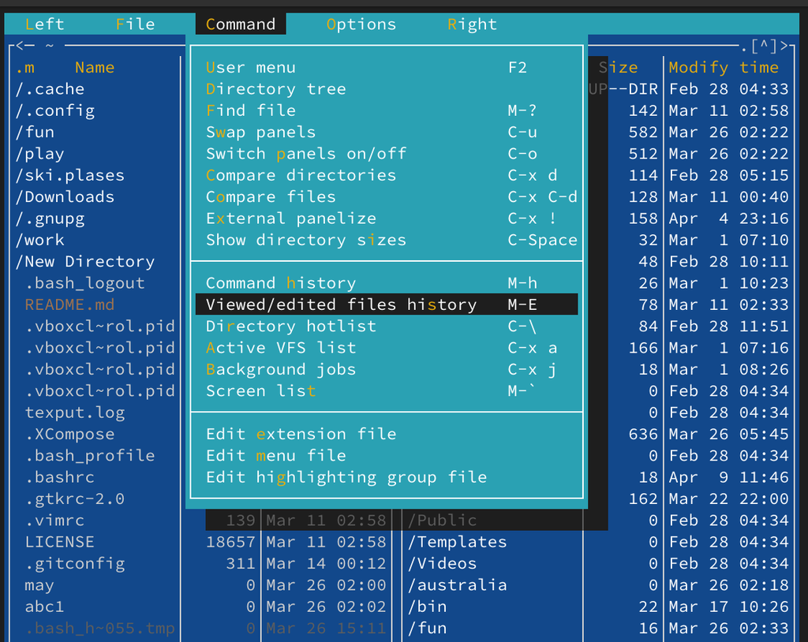

Подменю команда

## Задание по встроенному редактору mc

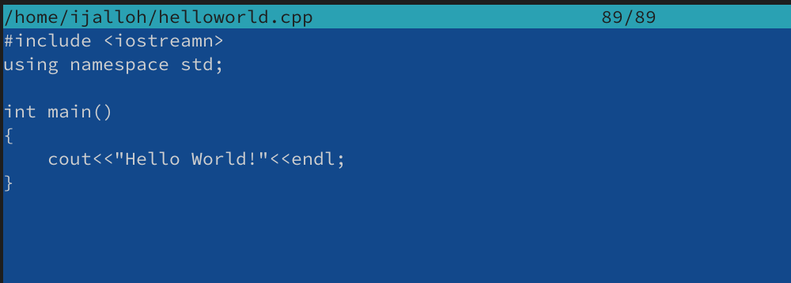

подсветка синтаксиса